# Structural Equation Models

Structural Equation Modeling

Tommaso Feraco

## Outline

- Introduction
- Identification
- Example
- Exercise
- Results

## Structural equation models

Up to now, we have seen how to model the relationship between different variables/constructs at the same time (path analysis) and how to build a measurement model with one or more latent variables.

A complete SEM takes both of these things and put them together

## The two parts of a SEM

- **The measurement model**
  $$\begin{aligned}
  x = \Lambda_x\xi + \delta
  y =\Lambda_y\eta + \epsilon
  \end{aligned}$$
- **The structural model**
  $$\begin{aligned}
  \eta = B\eta + \Gamma\xi + \zeta
  \end{aligned}$$

already seen in the first slides

## Matrices

These models (can) have all the possible matrices: - **Loadings and coefficients matrices**
$$\begin{aligned}
\Lambda^x & - relation among \xi and x
\Lambda^y & - relation among \eta and y
B & - relation among \eta and \eta
\Gamma & - relation among \xi and \eta
\end{aligned}$$
- **Covariance matrices**
$$\begin{aligned}
\Theta^\delta & - x errors
\Theta^\epsilon & - y errors
\Psi & - \eta errors
\Phi & - relations among \eta
\end{aligned}$$
Different models are allowew based on the way we define relationships among variables

## … `lavaan` matrices

`lavaan` does not distinguish between endogenous and exogenous variables. This leads to an easier parametrization and to four matrices only: 1. $\Lambda$ factor loadings matrix $[p x m]$ 1. $\Theta$ measurement residual errors covariance matrix $[p x p]$ 1. $B$ regression coefficients matrix $[m x m]$ 1. $\Psi$ residual structural errors covariance matrix $[m x m]$ With *p* being the number of manifest variables and *m* being the number of latent variables.

## The `lavaan` matrices

{Lambda: matrix of loadings}

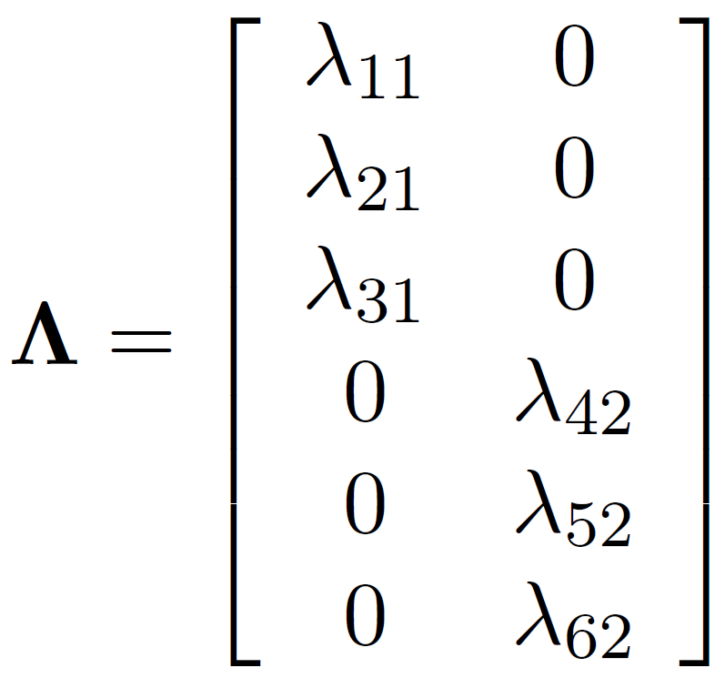

{Beta: regression coefficients}

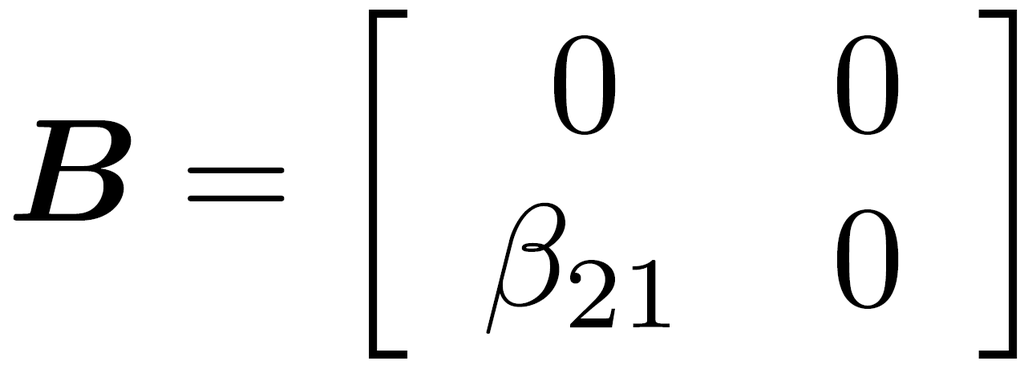

{Psi: residual structural errors matrix}

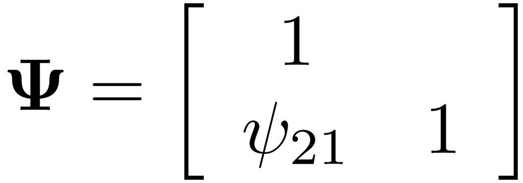

{Theta: observed variance-covariance matrix}

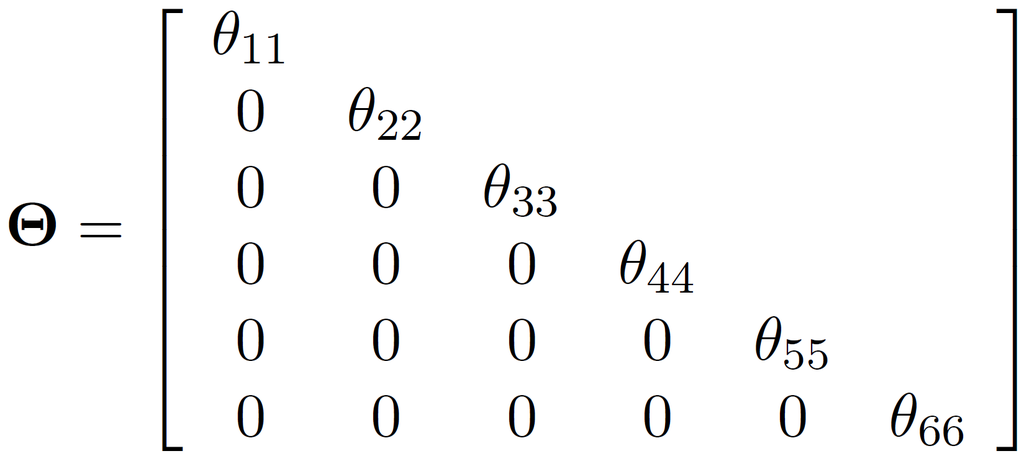

## A SEM example - simulation

```r
library(lavaan)
dSEM <- simulateData("xi =~ .74*x1 + .65*x2
                      eta =~ .56*y1 + .75*y2
                      eta ~ .30*xi
                     ", sample.nobs = 1000)
```

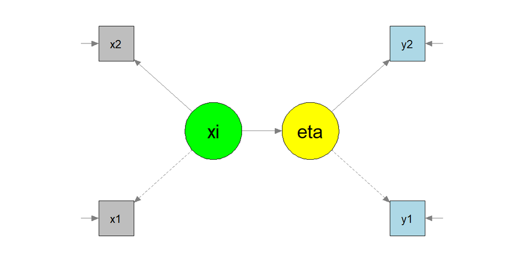

## A SEM example - specification and constraints

```r
fit <- sem(model = "xi =~ x1 + x2
                     eta =~ y1 + y2
                     eta ~ xi", data = dSEM)
```

**Constraints**

To estimate the model we need to set constraints: - the `sem` or `cfa` functions default is setting to 1 one loading for each latent variable - an alternative is to standardized latent variables using the `std.lv = TRUE` option

## Constraints: `default`

```
[...]
Latent Variables:
                   Estimate  Std.Err  z-value  P(>|z|)   Std.lv  Std.all
  xi =~
    x1                1.000                               0.769    0.644
    x2                0.728    0.296    2.464    0.014    0.560    0.476
  eta =~
    y1                1.000                               0.630    0.548
    y2                1.227    0.459    2.672    0.008    0.773    0.595

[...]
Variances:
                   Estimate  Std.Err  z-value  P(>|z|)   Std.lv  Std.all
   .x1                0.835    0.243    3.440    0.001    0.835    0.586
   .x2                1.070    0.136    7.865    0.000    1.070    0.773
   .y1                0.923    0.154    5.986    0.000    0.923    0.699
   .y2                1.092    0.229    4.766    0.000    1.092    0.646
    xi                0.591    0.245    2.409    0.016    1.000    1.000
   .eta               0.373    0.145    2.574    0.010    0.941    0.941

[...]
```

## Constraints: `std.lv=T`

```
[...]
Latent Variables:
                   Estimate  Std.Err  z-value  P(>|z|)   Std.lv  Std.all
  xi =~
    x1                0.769    0.160    4.818    0.000    0.769    0.644
    x2                0.560    0.119    4.710    0.000    0.560    0.476
  eta =~
    y1                0.611    0.119    5.148    0.000    0.630    0.548
    y2                0.750    0.147    5.113    0.000    0.773    0.595

[...]
Variances:
                   Estimate  Std.Err  z-value  P(>|z|)   Std.lv  Std.all
   .x1                0.835    0.243    3.440    0.001    0.835    0.586
   .x2                1.070    0.136    7.865    0.000    1.070    0.773
   .y1                0.923    0.154    5.986    0.000    0.923    0.699
   .y2                1.092    0.229    4.766    0.000    1.092    0.646
    xi                1.000                               1.000    1.000
   .eta               1.000                               0.941    0.941

[...]
```

## `lavaan` matrices

```r
inspect(fit, "std") # OR "est"
```

```
$lambda
     xi  eta
x1 0.64 0.00
x2 0.48 0.00
y1 0.00 0.55
y2 0.00 0.59

$theta
     x1   x2   y1   y2
x1 0.59
x2 0.00 0.77
y1 0.00 0.00 0.70
y2 0.00 0.00 0.00 0.65
```

```
$psi
      xi  eta
xi  1.00
eta 0.00 0.94

$beta
      xi eta
xi  0.00   0
eta 0.24   0
```

## SEM identification

Once again, remember that identification is a topic relevant to all structural equation models.

If an unknown parameter in $\theta$ can be written as a function of one or more elements of $\Sigma$, that parameter is identified.

If all unknown parameters in $\theta$ are identified, the model is identified. - the *t*-rule (again) - the *Two-Steps* rule

## *Two-Steps* rule

- *Step 1*. Treat the model as a confirmatory factor analysis: view the original $x$ and $y$ as $x$ variables and the original $\xi$ and $\eta$ as $\xi$ variables. The only relationship between latent variables of interest are their variance and covariance $Phi$. That is, ignore the $B$, $\Gamma$, and $\Psi$ elements.

  $\rightarrow$ apply CFA identification rules
- *Step 2*. Examine the latent variable equation of the original model ($\eta = B\eta + \Gamma\xi + \zeta$), assuming that each latent variable is an observed variable that is perfectly measured.

## *Two-Steps* rule

**Summary**

If the first step shows that the measurement parameters are identified and the second step shows that the latent variable model parameters also are identified, then this is suficient to identify the whole model.

## `Political democracy` dataset

Bollen (1989) studied the relation between industrialization in 1960 and political democracy of developing countries in 1960 and 1965.

We have 11 variables

```
   y1  y2   y3  y4  y5  y6   y7   y8  x1  x2  x3
1 2.5 0.0  3.3 0.0 1.2 0.0  3.7 3.33 4.4 3.6 2.6
2 1.2 0.0  3.3 0.0 6.2 1.1  6.7 0.74 5.4 5.1 3.6
3 7.5 8.8 10.0 9.2 8.8 8.1 10.0 8.21 6.0 6.3 5.2
```

A first latent variable, Industrialization ($I = x_1 + x_2 + x_3$)

A second latent variable, political democracy in 1960 ($D60 = y_1 + y_2 + y_3 + y_4$)

A third latent variable, political democracy in 1965 ($D65 = y_5 + y_6 + y_7 + y_8$).

`LET'S APLLY THE TWO-STEPS RULE`

## Step 1 - model plot

**The CFA model**

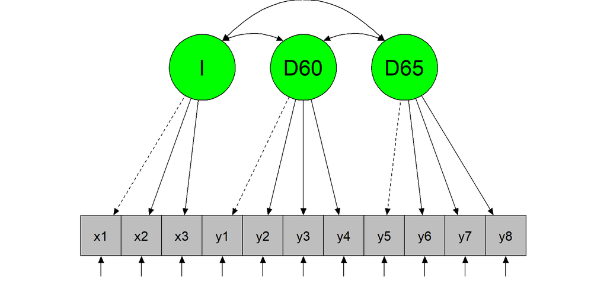

## Step 1 - model specification and results

**The CFA model**

```r
m <- "I =~ x1 + x2 + x3
D60 =~ y1 + y2 + y3 + y4
D65 =~ y5 + y6 + y7 + y8
"
```

```r
fit1 <- sem(m, data = PoliticalDemocracy)
fit1@Fit@converged
```

```
[1] TRUE
```

`PARAMETERS ARE ALL IDENTIFIED. LET'S GO TO STEP 2`

## Step 2 - model plot

**The structural model**

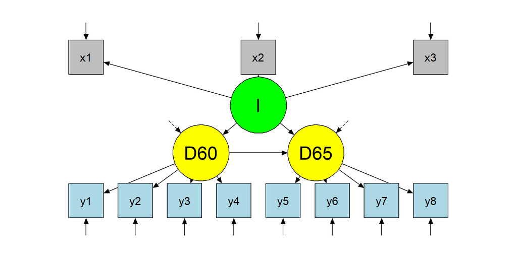

## Step 2 - model specification and results

**The structural model**

```r
m2 <- "I =~ x1 + x2 + x3
D60 =~ y1 + y2 + y3 + y4
D65 =~ y5 + y6 + y7 + y8
D65 ~ I + D60
D60 ~ I
"
```

```r
fit2 <- sem(m2, data = PoliticalDemocracy)
fit2@Fit@converged
```

```
[1] TRUE
```

`STRUCTURAL PARAMETERS ARE ALSO IDENTIFIED.`

`LET'S DEFINE THE MODEL CONSIDERING LONGITUDINAL MEASURES`

## Final model

**The modified model**

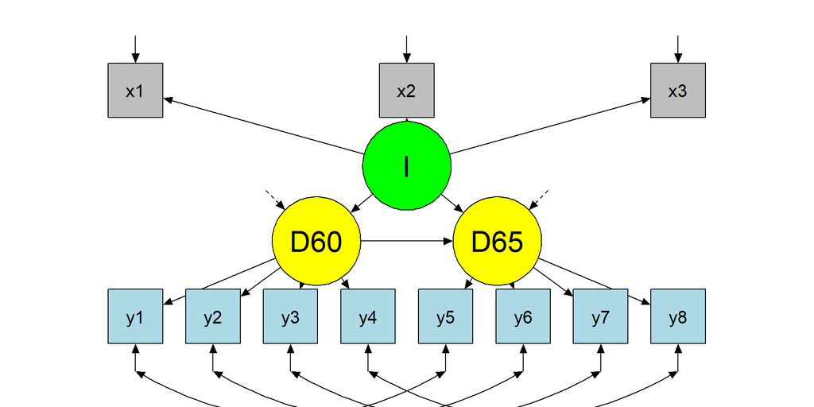

## Final model specification

**The modified model**

```r
m3 <- "I =~ x1 + x2 + x3
D60 =~ y1 + y2 + y3 + y4
D65 =~ y5 + y6 + y7 + y8
D65 ~ I + D60
D60 ~ I
y1 ~~ y5
y2 ~~ y6
y3 ~~ y7
y4 ~~ y8
"
```

`SAME ITEMS AT DIFFERENT TIME POINTS HAVE CORRELATED RESIDUALS`

## Final model results

**The modified model**

```r
(fit3 <- sem(m3, data = PoliticalDemocracy))
```

```
lavaan 0.6-19 ended normally after 58 iterations

  Estimator                                         ML
  Optimization method                           NLMINB
  Number of model parameters                        29

  Number of observations                            75

Model Test User Model:

  Test statistic                                50.835
  Degrees of freedom                                37
  P-value (Chi-square)                           0.064
```

```r
inspect(fit3, what = "fitmeasures")[
  c("cfi", "srmr", "rmsea")]
```

```
  cfi  srmr rmsea
0.980 0.050 0.071
```

`MODEL FIT IS GOOD!`

## Model comparisons

```r
anova(fit1,fit2,fit3)
```

```
Chi-Squared Difference Test

     Df  AIC  BIC Chisq Chisq diff RMSEA Df diff Pr(>Chisq)
fit3 37 3166 3233  50.8
fit1 41 3180 3238  72.5       21.6 0.242       4    0.00024 ***
fit2 41 3180 3238  72.5        0.0 0.000       0
---
Signif. codes:  0 '***' 0.001 '**' 0.01 '*' 0.05 '.' 0.1 ' ' 1
```

## Model comparisons

We can also compare the models using fit indices:

|  | chisq | df | cfi | tli | srmr | rmsea | aic | bic |
| --- | --- | --- | --- | --- | --- | --- | --- | --- |
| model1 | 72 | 41 | 0.95 | 0.94 | 0.055 | 0.101 | 3180 | 3238 |
| model2 | 72 | 41 | 0.95 | 0.94 | 0.055 | 0.101 | 3180 | 3238 |
| model3 | 51 | 37 | 0.98 | 0.97 | 0.050 | 0.071 | 3166 | 3233 |

`WHAT IS THE BEST MODEL? QUESTIONS? COMMENTS?`

# Exercise

## The `EAT` dataset

The dataset includes 13 items that measure ‘peer pressure’, ‘social media use’, ‘social comparison’, and ‘eating disorders’.

```r
load("../data/Exercise4_1.Rdata")
round(head(dE4_1),2)
```

```
    PP1   PP2   PP3   PP4   SM1   SM2   SM3   SM4  SC1   SC2   SC3   ED1   ED2
1  0.23  1.91  0.59 -0.70  2.31  1.06  1.43 -0.77  1.2  2.20  0.18 -0.38  1.61
2 -0.65 -3.18 -0.84 -0.43  0.69  0.10  1.24  0.51 -1.9 -1.17 -1.23 -1.74 -1.73
3  0.26 -1.46 -0.43 -0.05 -0.21 -0.46 -0.02  1.26  1.4  1.03  0.90  1.07  2.04
4 -0.68 -0.29 -0.08 -2.24 -0.64  0.47 -0.76  0.58  1.2  0.97  2.73  0.71  0.32
5 -0.06  0.89  0.04 -0.41  0.17  1.02  0.18  0.61  3.7  1.38  1.85  1.25  0.66
6 -0.29 -2.74 -0.52  2.58  0.15 -1.08  1.08  0.99  1.3 -0.24  0.93 -0.97 -0.68
```

[figure not shown]

## The theoretical model

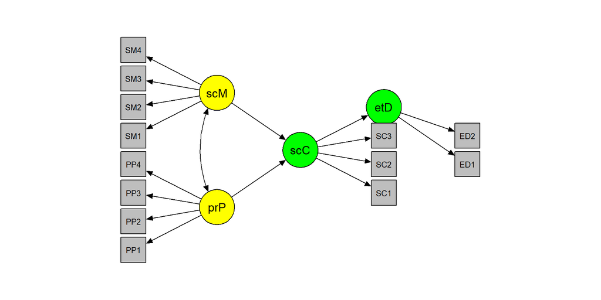

## The exercise

1. Apply the two-step rule:
   1. Test the CFA model
   2. Test the structural model
2. Inspect model results and fit indices
   - Are the hypotheses confirmed?
   - Does the model fit the data well?
3. If the model is not satisfactory, understand why and change it
4. Draw the model (in `R`, ppt, or with a pencil)
5. Try to fit a simple path model using sum scores instead of latent scores

## Model specification

`STEP 1 and 2`

```r
m1 <- "
 # CFA model
 peerPressure =~ PP1 + PP2 + PP3 + PP4
 socialMedia =~ SM1 + SM2 + SM3 + SM4
 socialComparison =~ SC1 + SC2 + SC3
 eatingDisorder =~ ED1 + ED2
"
fit1 <- sem(m1, data = dE4_1, std.lv=T)
fit1@Fit@converged
m2 <- "
 [...]
 # Structural model
 eatingDisorder ~ socialComparison
 socialComparison ~ peerPressure + socialMedia"
fit2 <- sem(m2, data = dE4_1, std.lv=T)
fit2@Fit@converged
```

`OK?`

## Results and fit

```r
summary(fitE4_1, std=T)
```

```
[...]
Regressions:
                     Estimate  Std.Err  z-value  P(>|z|)   Std.lv  Std.all
  eatingDisorder ~
    socialComparsn      0.344    0.047    7.322    0.000    0.356    0.356
  socialComparison ~
    peerPressure        0.139    0.038    3.636    0.000    0.125    0.125
    socialMedia         0.455    0.049    9.221    0.000    0.411    0.411

[...]
```

```r
fitmeasures(fitE4_1,
            fit.measures =
            c("cfi", "tli", "srmr", "rmsea"))
```

```
  cfi   tli  srmr rmsea
0.880 0.846 0.044 0.065
```

## Model modification

```r
modificationIndices(fitE4_1, sort. = T)[1:10,]
```

```
                 lhs op rhs  mi   epc sepc.lv sepc.all sepc.nox
120              SM1 ~~ SC2 329  0.56    0.56     0.63     0.63
49       socialMedia =~ SC2  57  0.38    0.38     0.29     0.29
57  socialComparison =~ SM1  55  0.29    0.32     0.28     0.28
121              SM1 ~~ SC3  52 -0.23   -0.23    -0.23    -0.23
50       socialMedia =~ SC3  31 -0.28   -0.28    -0.21    -0.21
119              SM1 ~~ SC1  22 -0.15   -0.15    -0.15    -0.15
143              SC1 ~~ SC3  19  0.29    0.29     0.28     0.28
74               PP1 ~~ PP2  18  0.66    0.66     1.20     1.20
97               PP3 ~~ PP4  15  0.13    0.13     0.11     0.11
58  socialComparison =~ SM2  13 -0.15   -0.16    -0.14    -0.14
```

```r
m2.1 <- "
[...]
# Residual correlations
SM1 ~~ SC2
"
fitmeasures(fit2.1, ...)
```

```
  cfi   tli  srmr rmsea
0.995 0.994 0.023 0.013
```

## Sum scores

```r
d2 <- data.frame(
  peerPressure = dE4_1$PP1 + dE4_1$PP2 + dE4_1$PP3 + dE4_1$PP4,
  socialMedia = dE4_1$SM1 + dE4_1$SM2 + dE4_1$SM3 + dE4_1$SM4,
  socialComparison = dE4_1$SC1 + dE4_1$SC2 + dE4_1$SC3,
  eatingDisorder = dE4_1$ED1 + dE4_1$ED2)
path <- "
eatingDisorder ~ socialComparison
socialComparison ~ peerPressure + socialMedia"
fitP <- sem(path, d2)
fitmeasures(fitP, fit.measures =
              c("cfi", "tli", "srmr", "rmsea"))
```

```
  cfi   tli  srmr rmsea
0.978 0.946 0.019 0.037
```

## Sum scores VS latent scores

However, the debate is still open:

- Thinking twice about sum scores
- Thinking thrice about sum scores, and then some more about measurement and analysis
- Psychometric properties of sum scores and factor scores differ even when their correlation is 0.98: A response to Widaman and Revelle
- Or some more Schimmack:
  - Schimmack vs Gelman 1
  - Schimmack vs Gelman 2

## The ground truth

```r
# peer pressure AND social media -> social comparison -> eating disorder
mE4_1 <- "
 # CFA model
 peerPressure =~ .75*PP1 + .72*PP2 + .59*PP3 + .65*PP4
 socialMedia =~ .45*SM1 + .55*SM2 + .59*SM3 + .65*SM4
 socialComparison =~ .81*SC1 + .75*SC2 + .86*SC3
 eatingDisorder =~ .70*ED1 + .65*ED2

 # Structural model
 eatingDisorder ~ .37*socialComparison
 socialComparison ~ .23*peerPressure + .41*socialMedia

 # Misspecifications
 # within construct
 PP1 ~~ .43*PP2
 # between construct
 SM1 ~~ .53*SC2
"
```

## The indifference of the indicator

- How many indicators do we need?
- How should I select them?
- … `LET'S SEE THE ADDITIONAL CODE`